# PROSPER LENDING PLATFORM

## INVESTIGATION OVERVIEW

Prosper is an online peer-to-peer lending marketplace in the United States. In this investigation, I wanted to understand how the Prosper platform works. The main focus been on the platform's loan amounts and interest rates, borrowers' credit scores and credit profiles and how Prosper grades her borrowers.

## DATASET OVERVIEW

The data consists of about 80 variables of about 113,000 borrowers from 2005 to 2014 including: loan categories, borrowers' interest rate, credit profiles, credit scores and grades, employment status and others.

## INTEREST RATES AT PROSPER

At Prosper Loans, interest paid by borrowers on loans are very crucial. When borrowers apply for a loan at Prosper there are probably two main things they want to know. Will they be approved for the loan and if so, what will the interest rate be? The distribution of interest rates at Prosper is shown in the histogram below. The distribution is roughly multi-modal with rates ranging from about 5% to about 35%, with peaks at 15%, 20%, between 30% to 35%. The dataset was investigated to determine what factors influence these rates.

### DISTRIBUTION OF INTEREST RATES¶

The distribution of interest rates is roughly bimodal with peaks at 15% and between 30% and 35%.

```
(0.0, 0.4)
```

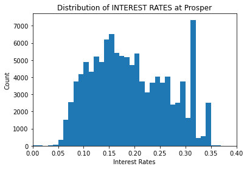

### DISTRIBUTION OF LOAN AMOUNT

At Prosper, within the period of this dataset, borrowers could get loans from 1,000𝑡𝑜 35,000. The distribution is multi-modal with major peaks at 5,000, 10,000 and $15,000

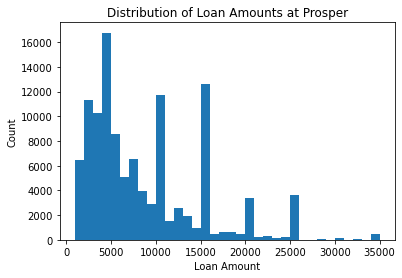

### EMPLOYMENT STATUS AND INTEREST RATES

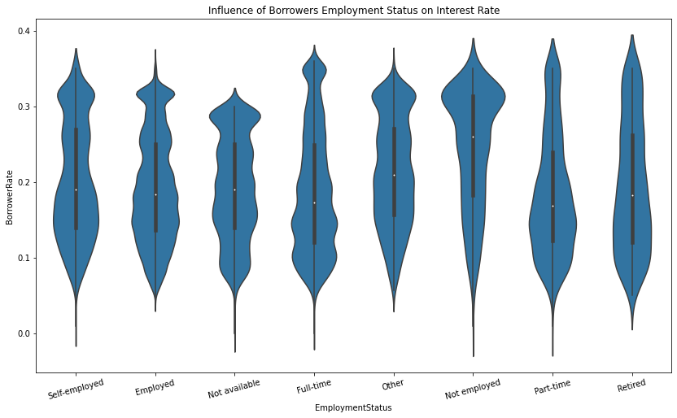

### INTEREST RATE AND BORROWERS' LOAN AMOUNT

Interest rate and borrowers loan amount have a negative correlation. The lower the loan amount, the higher the interest rate, though, there seems to be little difference between the interest rates of loan amounts between 25,000𝑎𝑛𝑑 35,000.

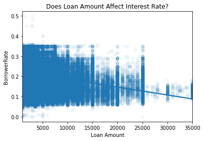

### DISTRIBUTION OF BORROWERS' CREDIT SCORE

From 2005 to 2009, Prosper accepted borrowers with not so perfect credit to get loans from Prosper. Loans were available to borrowers with even non-complete credit scores in some cases, but after 2009, credit scores of borrowers seems to have improved with minimum of about 600.

```
(-44.45, 933.45)
```

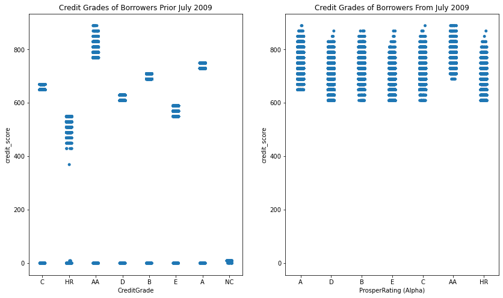

### INTEREST RATES AND BORROWERS' CREDIT SCORES

There appears to be a direct relationship between borrowers' credit scores and interest rates. The higher the credit scores, the lower the interest rates. Borrowers with no credit scores, that is, first time borrowers also have varying interest rates majorly from about 5% to 35%.

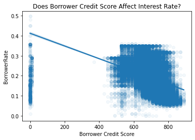

### DISTRIBUTION OF PROSPER RATING

Credit scores prior July 2009 fell between 0 (those without credit scores) and about 850 with AA having the highest credit scores followed by A, B, C, D, E and HR. AA grades appears to have credit scores majorly above 700, A between 640-780, B between 630-700, C between 620-650, D between 580-640, E between 570-600, HR between 400-560...this is not very clear. Its just an approximation!.

While from July 2009, there is considerable improvement on the credit scores of borrowers at prosper loans. Credit scores are between 600 and about 850.

While there is a visible increase in high credit score borrowers after July, 2009 (credit scores of borrowers have improved), majority of Prosper loans borrowers have average credit scores with C rating being the most popular.

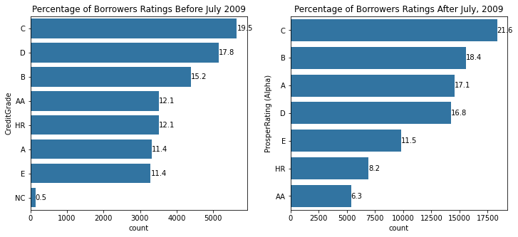

### BORROWERS' RATING AND INTEREST RATES

Prior July 2009, some borrowers with average or low ratings outperformed those with high ratings with interest rates below their minimum threshold, the same is seen after July 2009. In the same vein, some borrowers with high ratings performed poorly during these periods with interest rates above their maximum.

```
(7.5, -0.5)
```

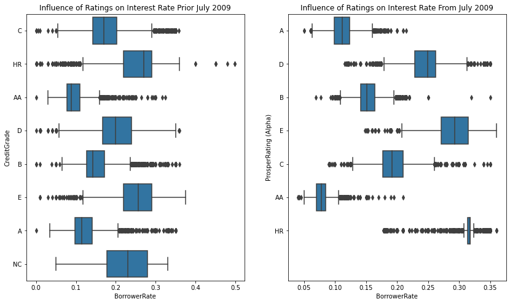

### BORROWERS' CREDIT PROFILES AND INTEREST RATE

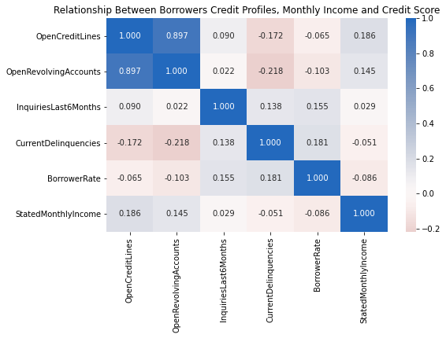

### BORROWERS' ESTIMATED LOSS, RATINGS AND INTEREST RATE

The plot below indicates that borrowers with lower estimated loss has lower interest rates. Borrowers with lower estimated loss have higher prosper rating with the highest being AA and the least HR.

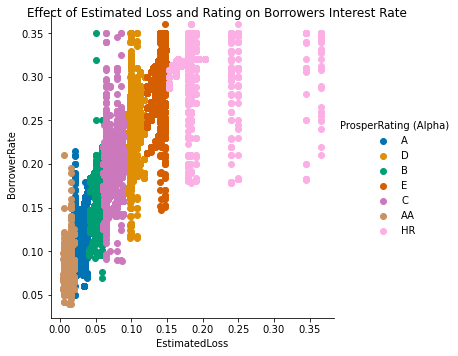

# CONCLUSION

Borrowers can access loans of up to $35,000 from Prosper. Their credit profiles and scores submitted at the time of loan listing is used to determine their estimated loss, yield and return to prosper. Based off these estimates, custom risk scores built using historical Prosper data, credit score, borrower's monthly income and loan amount, prosper assign credit ratings (AA-HR) and interest rates on borrowers' loans. These rates are fixed through out the life of the loan for a period of 12, 36 and 60 months.

While applicants with top credit scores will get better interest rates, borrowers with less than perfect credit can get loans too from Prosper. Loans are available to borrowers with credit scores as low as about 600. Although there are about 20 loan categories available at prosper, a borrower's best bet will be loans for debt consolidation, home improvement and personal loans.

Investors aren't left out at prosper. Although some loans appears to have more yield/return to the investors, I will advise investors to spread out their investments as even the highest inestment yield may be hampered by default payments and even charged off to the detriment of the investor.